# Diving deep: convolution output channels

Date: May 25, 2020

Table of contents:

- Setting up
- Experiment

Convolutional neural networks seems to do the job really well. They bring the dimensions of the image down, extract features out with a much lower footprint than fully connected layers. But what are the kernels doing? Is there an intuition behind them?

Today, we will try to train a conventional CNN on the CIFAR-10 dataset, and then poke around at the kernels. The amount of images in this post is quite large, so we only get to do 1 kind of experiment only. We will be poking around CNNs more in the future though.

## Setting up

As usual, here's what we need to import:

```python
import torch
import torch.nn as nn
import torch.optim as optim
import torchvision.datasets as datasets
import torchvision
import torchvision.transforms as transforms
import numpy as np
import matplotlib.pyplot as plt
import time
from PIL import Image
```

Then let's import CIFAR-10. The mean and standard deviation values I got from experimenting with it a little bit:

```python
means = torch.Tensor([0.4914, 0.4822, 0.4465])
stds = torch.Tensor([0.2470, 0.2435, 0.2616])
transforms = transforms.Compose([transforms.RandomHorizontalFlip(),
                                 transforms.RandomRotation(10),
                                 transforms.ToTensor(),
                                 transforms.Normalize(means, stds)])
dl = torch.utils.data.DataLoader(datasets.CIFAR10("datasets/", download=True,
                                                  train=True, transform=transforms),
                                 batch_size=1000,
                                 shuffle=True)
dl_test = torch.utils.data.DataLoader(datasets.CIFAR10("datasets/", download=True,
                                                       train=False, transform=transforms),
                                      batch_size=100,
                                      shuffle=True)
stds = stds.unsqueeze(-1).unsqueeze(-1).expand(-1, 32, 32)
means = means.unsqueeze(-1).unsqueeze(-1).expand(-1, 32, 32)
```

```
Files already downloaded and verified
Files already downloaded and verified
```

Note that we're correcting `means` and `stds` so that it matches the images' dimensions, so we can convert back and forth quickly. Let's see some of the images:

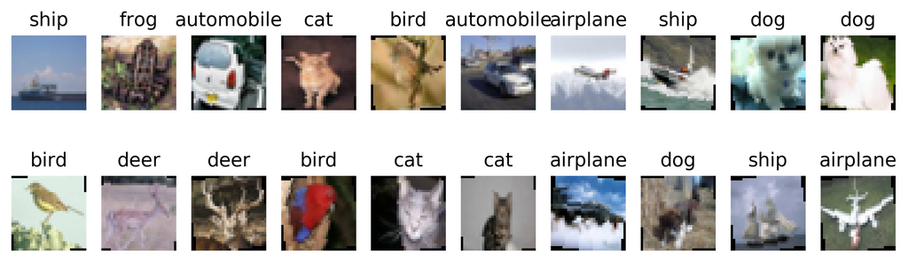

```python
categories = ["airplane", "automobile", "bird", "cat", "deer", "dog", "frog", "horse", "ship", "truck"]
imgs, labels = next(iter(dl)); plt.figure(num=None, figsize=(10, 3), dpi=350)
for i in range(20):
    plt.subplot(2, 10, i+1); plt.imshow((imgs[i] * stds + means).permute(1, 2, 0))
    plt.title(categories[labels[i]]); plt.axis("off")
```

Yep, everything seems okay. Let's create the network:

```python
class Net(nn.Module):
    def __init__(self):
        super().__init__()
        self.conv1 = nn.Conv2d(3, 32, 3, padding=1) # 32x32 -> 32x32
        self.conv2 = nn.Conv2d(32, 32, 3, padding=1) # 32x32 -> 16x16
        self.conv3 = nn.Conv2d(32, 64, 3, padding=1) # 16x16 -> 16x16
        self.conv4 = nn.Conv2d(64, 64, 3, padding=1) # 16x16 -> 8x8
        self.conv5 = nn.Conv2d(64, 128, 3, padding=1) # 8x8 -> 4x4
        self.pool = nn.MaxPool2d(2); self.relu = nn.ReLU(); self.logSoftmax = nn.LogSoftmax(1)
        self.batchnorm1 = nn.BatchNorm2d(32)
        self.batchnorm2 = nn.BatchNorm2d(64)
        self.fc1 = nn.Linear(128 * 4 * 4, 300); self.fc2 = nn.Linear(300, 10)
        self.dropout = nn.Dropout(0.5)
        self.times, self.losses, self.accuracies = [], [], []
    def forward(self, x):
        x = self.batchnorm1(self.pool(self.relu(self.conv2(self.relu(self.conv1(x))))))
        x = self.batchnorm2(self.pool(self.relu(self.conv4(self.relu(self.conv3(x))))))
        x = self.pool(self.relu(self.conv5(x)))
        x = self.dropout(x.contiguous().view(-1, 128 * 4 * 4))
        x = self.dropout(self.relu(self.fc1(x)))
        return self.logSoftmax(self.fc2(x))
    def fit(self, epochs):
        optimizer = optim.Adam(self.parameters(), lr=0.003, weight_decay=1e-5)
        count, lossFunction = 0, nn.NLLLoss()
        lastTime, initialTime = (self.times[-1] if len(self.times) > 0 else 0), time.time()
        for epoch in range(epochs):
            for imgs, labels in dl:
                count += 1; optimizer.zero_grad(); imgs, labels = imgs.cuda(), labels.cuda()
                loss = lossFunction(self(imgs), labels); loss.backward(); optimizer.step()
                if count % 30 == 0:
                    self.eval()
                    test_imgs, test_labels = next(iter(dl_test));self.losses.append(loss.item())
                    self.accuracies.append((torch.argmax(self(test_imgs.cuda()), dim=1) == test_labels.cuda()).sum())
                    self.times.append(lastTime + time.time()-initialTime); self.train()
                    print(f"\rProgress: {np.round(100*count/(epochs*len(dl)))}%, loss: {self.losses[-1]}, accuracy: {self.accuracies[-1]}/100    ", end="")
        return torch.Tensor(self.losses), torch.Tensor(self.accuracies), torch.Tensor(self.times)
net = Net().cuda()
losses, accuracies, times = net.fit(30)
```

```
Progress: 100.0%, loss: 0.532489001750946, accuracy: 86/100
```

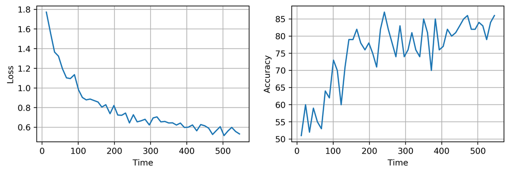

```python
plt.figure(num=None, figsize=(10, 3), dpi=350)
plt.subplot(1, 2, 1); plt.grid(True)
plt.plot(times, losses); plt.xlabel("Time"); plt.ylabel("Loss")
plt.subplot(1, 2, 2); plt.grid(True)
plt.plot(times, accuracies); plt.xlabel("Time"); plt.ylabel("Accuracy"); pass
```

86% accuracy. I'd say we did a pretty good job, because my GPU is almost 6 years old by now and can only handle 2.1 teraflops. This is around 1/6 of the current average consumer GPU and 1/15 of the beefiest consumer GPU. It was difficult fine tuning it though. Rising to around 65% is stupid easy, as any throwaway network (even a fully connected one) will just do. Rising to 70-75% we need to fine tune the number of convolution layers and their channels. Rising to 75%-80% we need to add simple bells and whistles like dropout, L2 regularization and fine tune the learning rate even more. Rising to 80-85% we need batch normalization.

## Experiment

The idea is that we are going to give it a variety of images, and get the values after every convolution and its associated activation. The hope is to be able to see how the decision making process looks like as we progress deeper into the network.

Let's see the size of the internal kernels:

```python
for param in net.parameters():
    if (len(param.shape) == 4): print(param.shape)
```

```
torch.Size([32, 3, 3, 3])
torch.Size([32, 32, 3, 3])
torch.Size([64, 32, 3, 3])
torch.Size([64, 64, 3, 3])
torch.Size([128, 64, 3, 3])
```

Here, we're defining a `pickOut()` function, which picks out the output of the layer we want. Then there's a convenience `displayConvOutputs()` function to display every channel of every layer so we can see what's going on. Notice that we're adding these functions for the `Net` class above, and not stanalone functions, as I want to break it into bite-sized segments:

```python
def pickOut(self, x, convLayer=3):
    x = self.relu(self.conv1(x))
    if convLayer == 1: return x
    x = self.relu(self.conv2(x))
    if convLayer == 2: return x
    x = self.batchnorm1(self.pool(x))
    x = self.relu(self.conv3(x))
    if convLayer == 3: return x
    x = self.relu(self.conv4(x))
    if convLayer == 4: return x
    x = self.batchnorm2(self.pool(x))
    x = self.relu(self.conv5(x))
    if convLayer == 5: return x
    x = self.pool(x)
    x = self.dropout(x.contiguous().view(-1, 128 * 4 * 4))
    x = self.dropout(self.relu(self.fc1(x)))
    return self.logSoftmax(self.fc2(x))

def displayConvOutputs(self, imgs):
    for convLayer in range(5):
        output = self.pickOut(imgs.cuda(), convLayer + 1).cpu().detach()
        print(f"Conv layer: {convLayer + 1}")
        dim = output.shape[1]; plt.figure(num=None, figsize=(10, 4/dim*2.5*16), dpi=350)
        for i in range(dim):
            plt.subplot(4, dim/4, i+1); plt.axis("off"); plt.imshow(output[0][i])
        plt.show()

Net.pickOut = pickOut
Net.displayConvOutputs = displayConvOutputs
```

I suggest opening this in multiple tabs, to directly compare them. First is an image from the $\mathcal{N}(0, 1)$ distribution:

```
Conv layer: 1
```

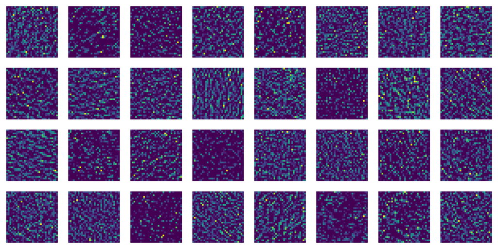

```
Conv layer: 2
```

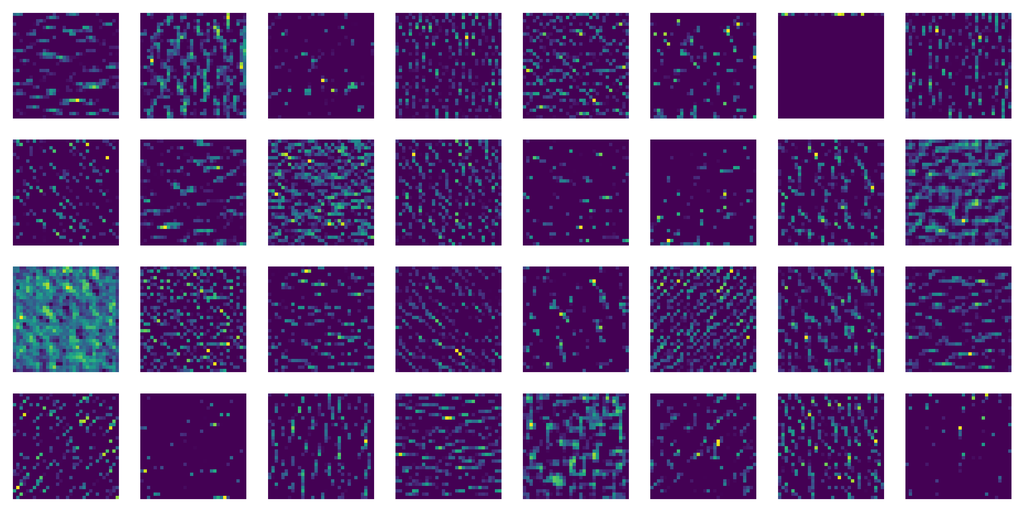

```
Conv layer: 3
```

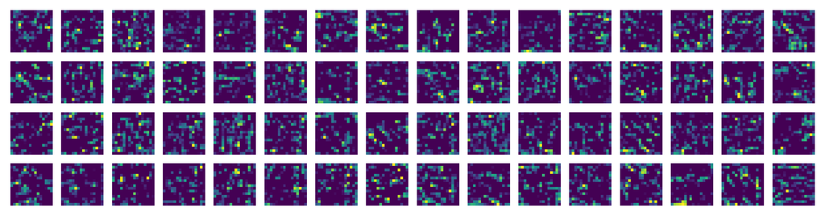

```
Conv layer: 4
```

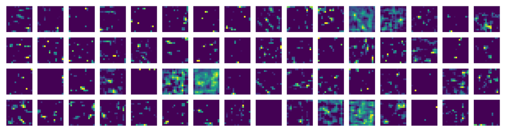

```
Conv layer: 5
```

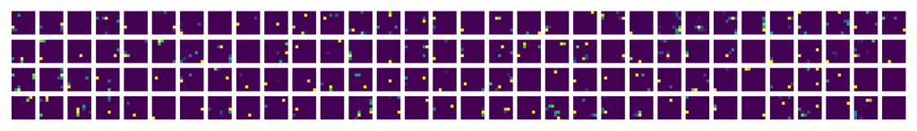

```python
net.displayConvOutputs(torch.normal(0, 1, (1, 3, 32, 32)))
```

Pretty much all channels in the first convolution layer detects minor repeating features, then in the second layer, it's quite clear that it's detecting certain features from the first layer only, and is sort of more generalized. In the third layer, there doesn't seem to be any pattern, and it feels a lot more random than the first 2 layers. Layer 4 is kinda like layer 3, but with less features. Also interesting how pretty much all channels have only few places where it lights up, but there are around 6 channel that predominantly lights up. Are these channels come from kernels that the network doesn't really need? In the last layer, pretty much all chaotic behavior and all 2d patterns disappear. What remains is a bunch of sparse random activations. This makes sense, as right after this layer is a pooling layer, and then a flatten layer, where all 2d information disappears.

Channels from an image from the $U(0, 1)$ distribution kinda looks exactly the same, so let's shift it over a bit to make it interesting. Now the image is from the $U(5, 6)$ distribution:

```
Conv layer: 1
```

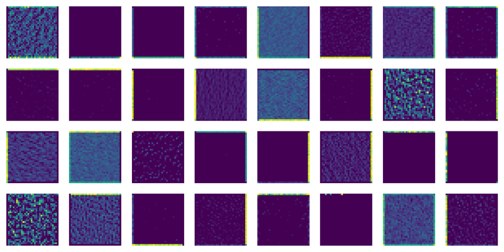

```
Conv layer: 2
```

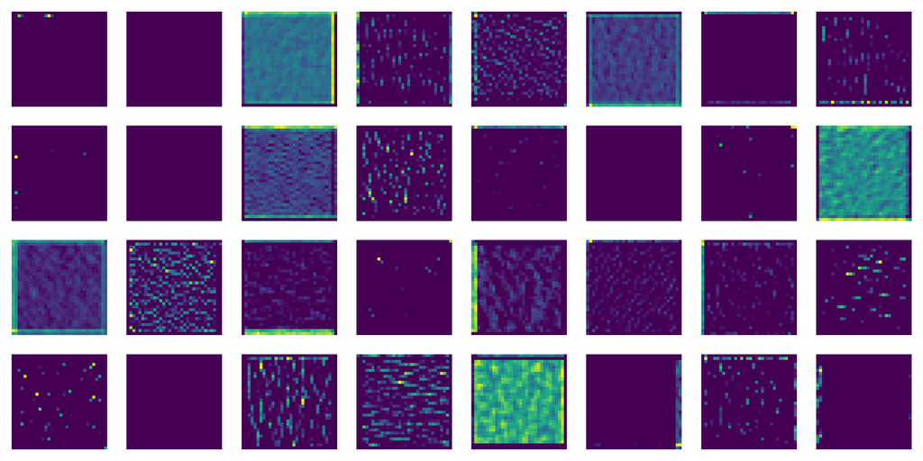

```
Conv layer: 3
```

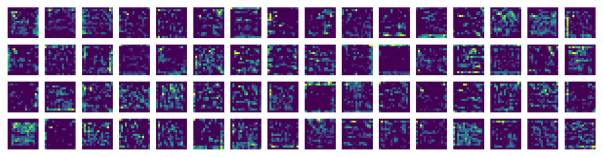

```
Conv layer: 4
```

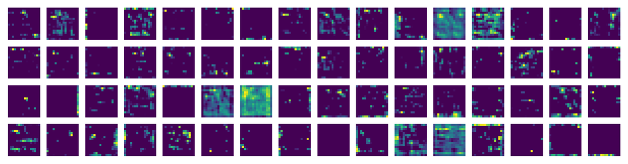

```
Conv layer: 5
```

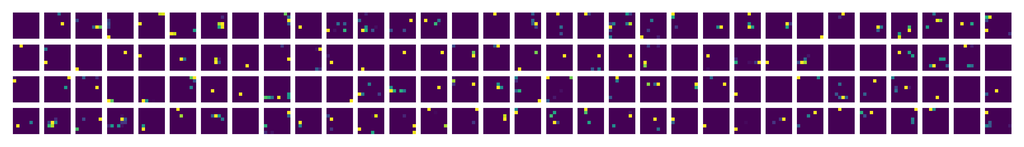

```python
net.displayConvOutputs(torch.rand(1, 3, 32, 32)+5)
```

It's interesting to note that a lot of activity from layer 1 and 2 has sort of died out, and no feature gets retained anymore. Is this expected? Yes I think so, because the images are originally in the $[0, 1]$ domain, and shifting the image that far out will effectively push image's domain outwards. This effect is like when I person suddenly becomes color blind, or actually becomes blind. When they are color blind, they have to sort of consciously map the new colors domain to the normal colors domain they already have and actively retrain their brain, or else they can't really recognize objects.

Note how the $\mathcal{N}(0, 1)$ distribution's channels don't really have distinguishable edges, while a lot of channels in this $U(5, 6)$ distribution does pick up on that. Remember that we're padding the missing edges by 0, so it's reasonable that a near-0 distribution will not pick up on the difference, while one that's far away will. Also note that although the domain is completely different, the output of layer 5 seems to be roughly the same as before and we can effectively treat this as an invariant and feel sure that it won't go off the rails when the input is whack.

This image is all zeros:

```
Conv layer: 1
```

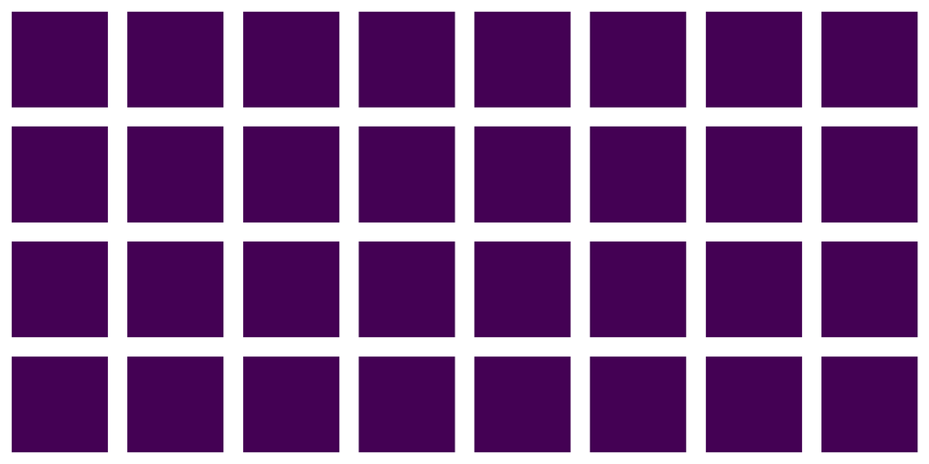

```
Conv layer: 2
```

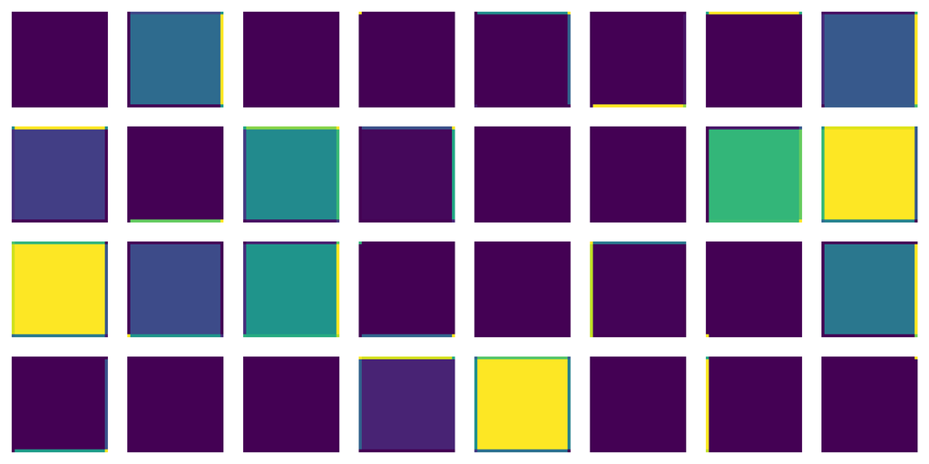

```
Conv layer: 3
```

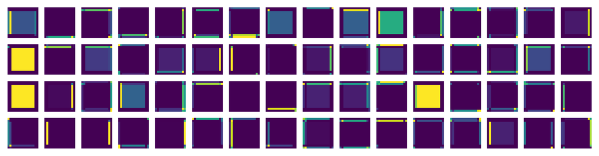

```
Conv layer: 4
```

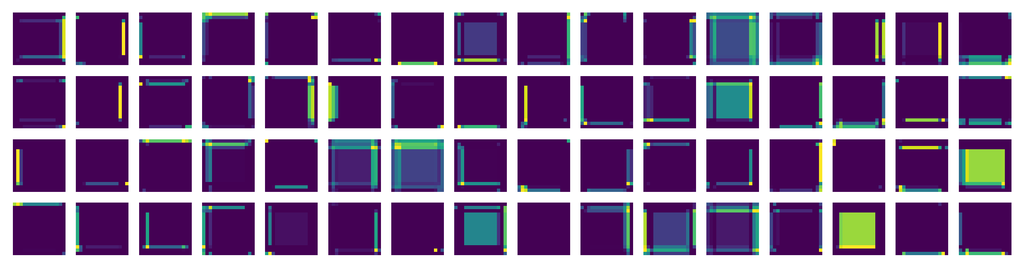

```
Conv layer: 5
```

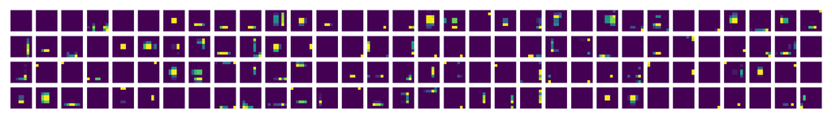

```python
net.displayConvOutputs(torch.zeros(1, 3, 32, 32))
```

When the image is all zeros, the first layer is completely empty, because there are no difference between pixels in a channel. Those pixels are not zero though, because there's a bias in [nn.Conv2d](https://pytorch.org/docs/stable/nn.html#conv2d)'s implementation for each channel. It's because of this that from layer 2 onwards there's a distinct border. Layer 5 still seems to be robust and still looks reasonable compared to the $\mathcal{N}(0, 1)$ distribution.

Let's try out an image with all ones:

```
Conv layer: 1
```

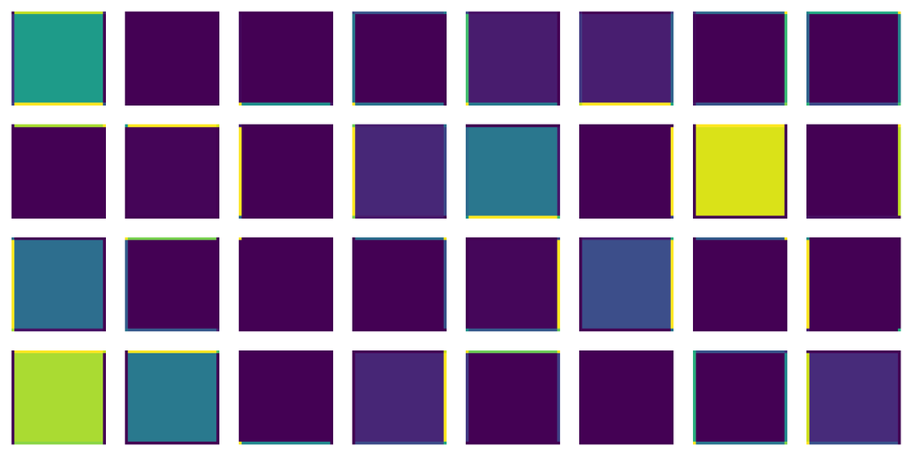

```
Conv layer: 2
```

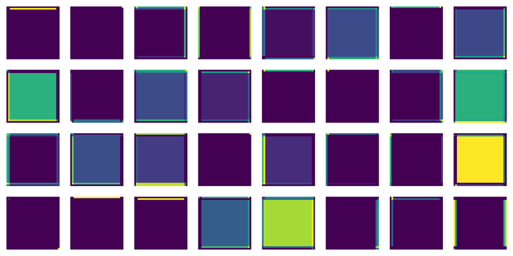

```
Conv layer: 3
```

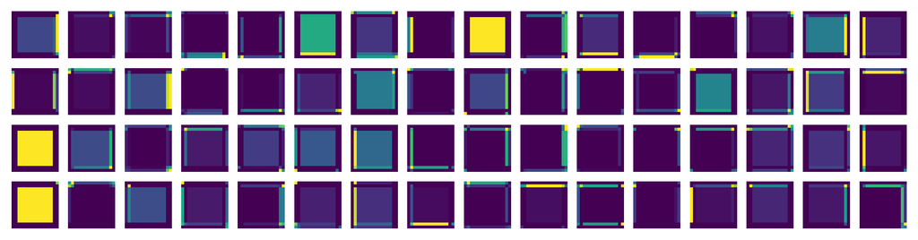

```
Conv layer: 4
```

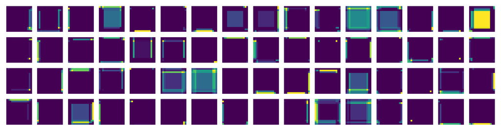

```
Conv layer: 5
```

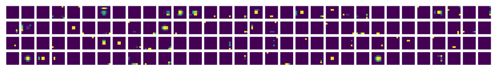

```python
net.displayConvOutputs(torch.ones(1, 3, 32, 32))
```

It's interesting to observe that for a completely uniform, but nonzero image, it still relies on the trickle-from-edge trick from the zero image. This sort of proves that the actual kernel values have a mean of around 0, because the effects of nearby pixels all gets canceled out. Let's run this just to make sure:

```python
print(net.conv1.weight.mean())
print(net.conv3.weight.mean())
print(net.conv5.weight.mean())
net.conv1.weight.std(), net.conv3.weight.std(), net.conv5.weight.std()
```

```
tensor(-0.0011, device='cuda:0', grad_fn=<MeanBackward0>)
tensor(-0.0134, device='cuda:0', grad_fn=<MeanBackward0>)
tensor(-0.0156, device='cuda:0', grad_fn=<MeanBackward0>)
```

```
(tensor(0.1406, device='cuda:0', grad_fn=<StdBackward0>),
 tensor(0.1128, device='cuda:0', grad_fn=<StdBackward0>),
 tensor(0.0934, device='cuda:0', grad_fn=<StdBackward0>))
```

Yep, just as predicted. What does this tell us? If you were actually paying attention to common image kernels and their values, you will see that the majority of them have the sum of all kernel elements equals to 0 or 1, and nothing else.

For example, sharpen, blur, and emboss all sum up to 1, while edge detect and sobel operator all sum up to 0. Sharpen, blur and emboss kinda have to preserve the average brightness, so they have to do all sum to 1. If they sum to 0.8, then the image will lose brightness, and will shift color dramatically, and if they sum to 1.2, then the image will have lots of pixels that falls outside the domain, thus white out the image. In contrast, edge detect and sobel operator are trying to detect features, and that kinda works well if the average brightness actually hovers around 0.

Back to the kernels in our convolutional layers. The way it's acting like this sort of suggests that the real feature extracting kernels will always hover around 0, and we shouln't expect the actual brightness and color/wavelength information to be propagated to deeper layers.

What if we now get the image with some 0 pixels and some 1 pixels with 50-50 chance? Turns out, it's pretty much like the $\mathcal{N}(0, 1)$ case, so there's not much to actually talk about. However, if we make 99% of the pixels 0, and 1%, then it should do something interesting:

```
Conv layer: 1
```

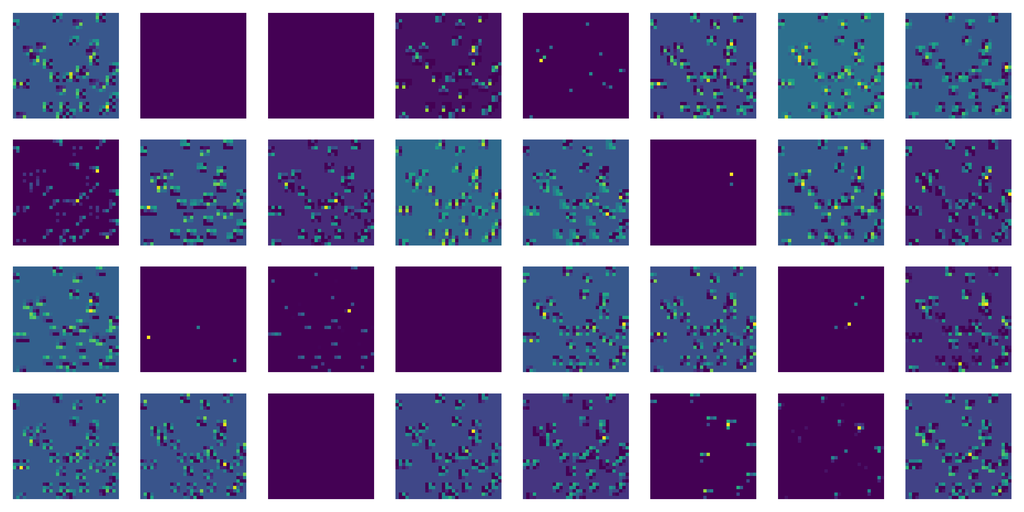

```
Conv layer: 2
```

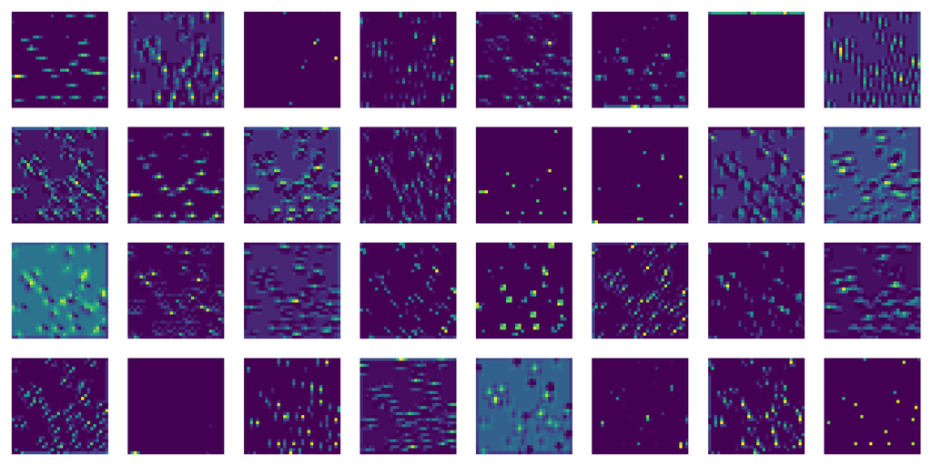

```
Conv layer: 3
```

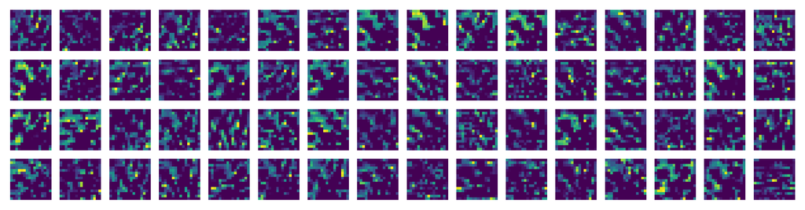

```
Conv layer: 4
```

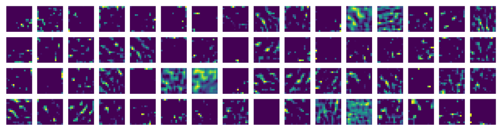

```
Conv layer: 5
```

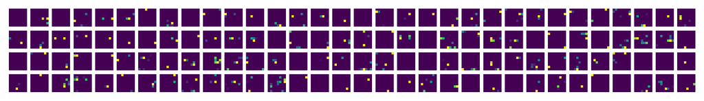

```python
net.displayConvOutputs(torch.floor(torch.rand(1, 3, 32, 32)*1.01))
```

We are generating a bunch of random numbers from 0 to 1.01. This means that there's a lot of numbers from 0 to 1, and a lot less numbers from 1 to 2. When we floor it, we get much more 0 than 1. For layers 1 and 2, the network sort of have to bunch around the 1-pixels to expand, because almost everywhere else is dead. You can also see a lower case "v" pattern appearing in pretty much every channel in layer 1 and 2, but it sort of gets erased from layer 3 onwards, as there's a batch normalization layer right after layer 2.